# HW1

Artur Sak

September 6, 2016

# Data

Load the data for this assignment into your R session with the following command:

```r
load(url("http://courseweb.lis.illinois.edu/~jguo24/SFTemps.rda"))
```

Check to see that the data were loaded by running:

```r
objects()
```

```
## [1] "dates"      "dayOfMonth" "month"      "temp"       "year"
```

This should show five variables: dates, dayOfMonth, month, temp, and year

Use the length() function to find out how many observations there are.

```r
length(dates)
```

```
## [1] 5534
```

# Exercises

1. What was the coldest temperature recorded in this time period?

```r
min(temp[!is.na(temp)])
```

```
## [1] 38.3
```

The coldest temperature is 38.3.

2. What was the average temperature recorded in this time period?

```r
summary(temp)
```

```
##    Min. 1st Qu.  Median    Mean 3rd Qu.    Max.    NA's
##   38.30   53.00   57.00   56.96   60.80   79.60      36
```

Mean: 56.96

3. What does the distribution of temperatures look like, i.e. are there roughly as many warm as cold days, are the temps clustered around one value or spread evenly across the range of observed temperatures, etc.?

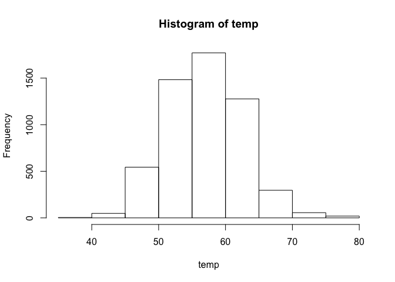

```r
hist(temp)
```

There are roughly as many cold days as there are warm days. The distribution appears to be normal with a slight skew to the right.

4. Examine the first few values of dates. These are a special type of data. Confirm this with class().

```r
head(dates)
```

```
## [1] "1995-01-01" "1995-01-02" "1995-01-03" "1995-01-04" "1995-01-05"
## [6] "1995-01-06"
```

```r
class(dates)
```

```
## [1] "Date"
```

5. We would like to convert the temperature from Farenheit to Celsius. Below are several attempts to do so that each fail.

```r
(temp -32)
```

**Error:**

No error message. Syntax is valid.

**Explanation:**

While the operation does not throw a syntax error the conversion itself is incorrect.

The conversion from Farenheit to Celsius is $T_c = (T_f - 32) * (5/9)$

```r
(temp - 32)5/9
```

**Error:**

Error: unexpected numeric constant in (temp - 32)5

**Explanation:**

This results in a syntax error because there is no operator between the parenthetical expression and the scalar, therefore the system does not know which mathematical operation to perform

```r
5/9(temp - 32)
```

**Error:**

Error: attempt to apply non-function

**Explanation:**

As in the last problem the expression is missing a mathematical operator between the scalar and the parentheses. In this case however, the system incorrectly treats 5/9 as a function due to the immediately proceeding parenthesis

```r
[temp - 32]5/9
```

**Error:**

Error unexpected ‘[’ in “[”

**Explanation:**

The system throws an error because the square bracket triggers a syntax error. When the complier reaches the square bracket and it attempts to access a value within a non-existent vector.

7. Run the following code to make a plot. (don’t worry right now about what this code is doing)

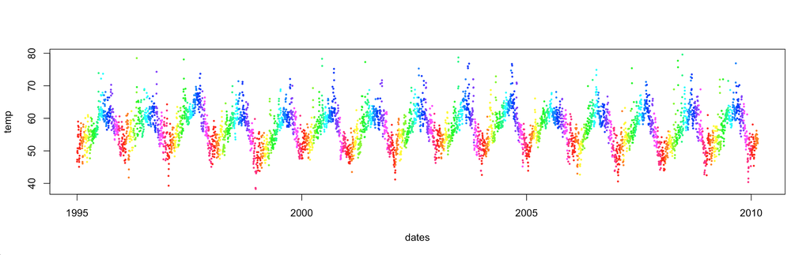

```r
plot(temp~dates, col = rainbow(12)[month], type="p", pch=19, cex = 0.3)
```

```r
tempC = (temp[!is.na(temp)] - 32) * (5/9)
```

- Make an interesting observation about temp in the Bay Area based on this plot (something that you couldn’t see with the calculations so far.)

*The temperatures fluctate based on the season.*

- What interesting question about the weather in the SF Bay Area would you like to answer with these data, but don’t yet know how to do it?

*To what extent can we accurately predict temperature fluctuations (i.e. the actual temperature values as well as prediction accuracy over longer measuring periods)?*

8. Use the following information about you to generate some random values:
1. Use the day of the month you were born for the mean of the normal.

```r
mean = 13
```

2. Use your year of birth for the standard deviation (sd) of the normal curve.

```r
sd = 1994
```

3. Generate 5 random values using the parameters from a and b. (See part ‘d’)
4. Assign the values to a variable named with your first name.

```r
artur = rnorm(5, mean, sd)
```

5. Provide the values generated.

```r
print(artur)
```

```
## [1]  1752.3669   880.1062   724.7507 -2420.9887 -3431.8200
```

9. Generate a vector called “normsamps” containing 100 random samples from a normal distribution with mean 2 and SD 1.

```r
normsamps = rnorm(100, 2, 1)
```

10. Calculate the mean and sd of the 100 values.

```r
mean(normsamps)
```

```
## [1] 2.069735
```

```r
sd(normsamps)
```

```
## [1] 1.044399
```

11. Use implicit coercion of logical to numeric to calculate the fraction of the values in normsamps that are more than 3.

```r
length(normsamps[normsamps > 3]) / length(normsamps)
```

```
## [1] 0.18
```

12. Look up the help for rnorm.

```r
?rnorm
```

You will see a few other functions listed.Use one of them to figure out about what answer you should expect for the previous problem. That is, find the area under the normal(2, 1) curve to the right of 3. This should be the chance of getting a random value more than 3. What value do you expect? What value did you get? Why might they be different?

```r
pnorm(3, 2, 1, lower.tail=FALSE)
```

```
## [1] 0.1586553
```

**Expected:** 0.1586553 **Actual:** 0.18

The values are likely different due to a sampling error (we limited to 100 random samples, whereas the sample size used for pnorm is likely larger).